# Extreme value analysis at Cabauw location

Author

Alexandre Tribut

Published

July 25, 2024

# 1 Stability plot

## 1.1 Generalized Pareto

### 1.1.1 Estimation of the storm threshold

#### 1.1.1.1 Measurements

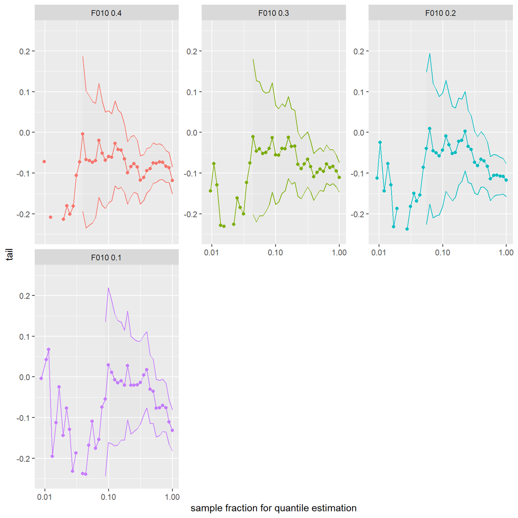

```r
tailindexplot_col(Cabauw_measure,12*6,columns = c("F010","F010","F010","F010"),fraq_min = 2,fix_y = c(-0.25,0.25),parameter = 'tail',peak_frac = c(0.4,0.3,0.2,0.1),winter=T)
```

#### 1.1.1.2 Weather model

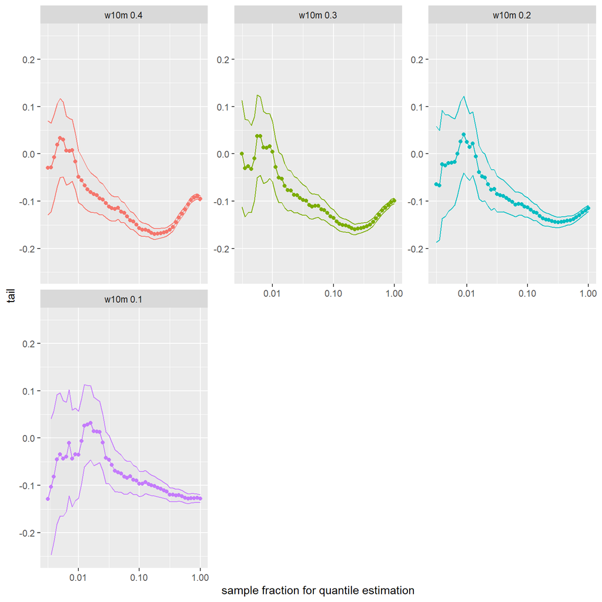

```r
tailindexplot_col(Cabauw_RACMO,4,columns = c("w10m","w10m","w10m","w10m"),fraq_min = 2.5,fix_y = c(-0.25,0.25),parameter = 'tail',peak_frac = c(0.4,0.3,0.2,0.1),winter = T)
```

> Why truncate the dataset on only winter values ?

The idea is that the distribution is more stationary over the winter season. With all-year, you have a mixture between less stormy summer weather and more stormy winter weather. The idea is that the tail would converge faster to a limiting shape than when you have a mixture of 2 tails (the heaviest tail will eventually dominate when the sample fraction tends to 0, but it takes longer than using already only the winter tail).

> Regarding the `PoT.html` notebook, we can assume that taking 0.3 highest values of the whole dataset is correct.

### 1.1.2 Stability with model

We check if the tail index is similar between the model and the measurements to see if it’s ok to use the model to estimate the tail.

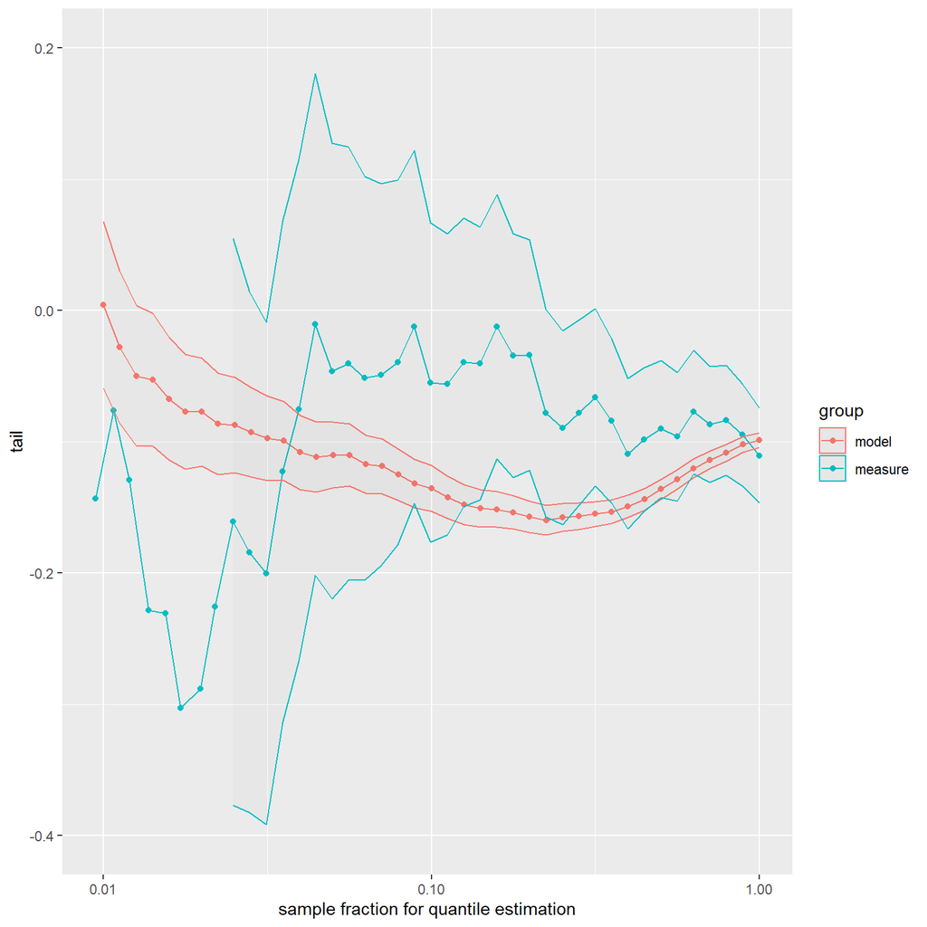

```r
stability_est_GP(data_model = Cabauw_RACMO, data_measure = Cabauw_measure, col_model='w10m',col_measure='F010', timestep_model=3,timestep_measure=1/6,fix_y = c(-0.4,0.2), parameter='tail',overlap = T,peak_frac = 0.3,winter = T)
```

```
[1] 6.434419
================================================================================[1] 5.615971
================================================================================================================================================================
```

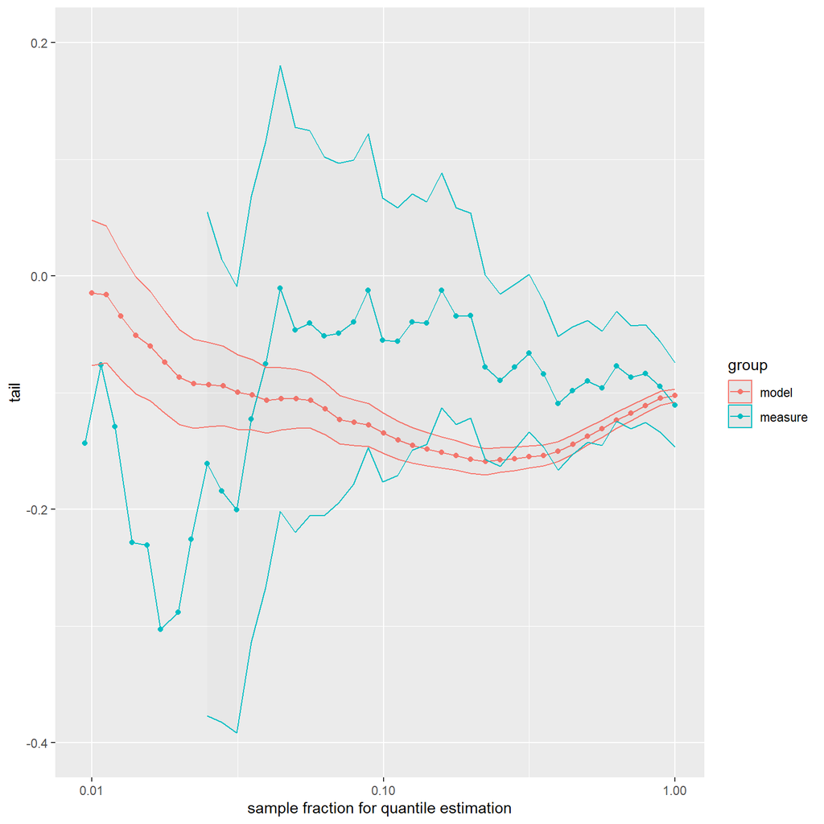

```
$df
             p         val          lb            ub   group
1  0.009992973 -0.01434940 -0.07647317  0.0477743806   model
2  0.011212384 -0.01580396 -0.07436581  0.0427578987   model
3  0.012576472 -0.03441913 -0.08866809  0.0198298379   model
4  0.014116237 -0.05088718 -0.10121876 -0.0005555944   model
5  0.015842014 -0.06008648 -0.10713705 -0.0130359039   model
6  0.017774471 -0.07402999 -0.11779034 -0.0302696348   model
7  0.019944610 -0.08655166 -0.12730408 -0.0457992386   model
8  0.022373099 -0.09218053 -0.13042060 -0.0539404635   model
9  0.025111607 -0.09303887 -0.12909952 -0.0569782104   model
10 0.028170470 -0.09403218 -0.12804150 -0.0600228576   model
11 0.031611690 -0.09947822 -0.13139012 -0.0675663307   model
12 0.035466270 -0.10180329 -0.13185339 -0.0717531915   model
13 0.039796214 -0.10649499 -0.13471507 -0.0782749022   model
```

[output cut: 72 more lines]

```r
stability_est_GP(data_model = Cabauw_RACMO, data_measure = Cabauw_measure, col_model='p10m',col_measure='F010', timestep_model=3,timestep_measure=1/6,fix_y = c(-0.4,0.2), parameter='tail',overlap = T,peak_frac = 0.3,winter=T)
```

#### 1.1.2.1 Comparison between potential wind and normal wind at 10m with RACMO

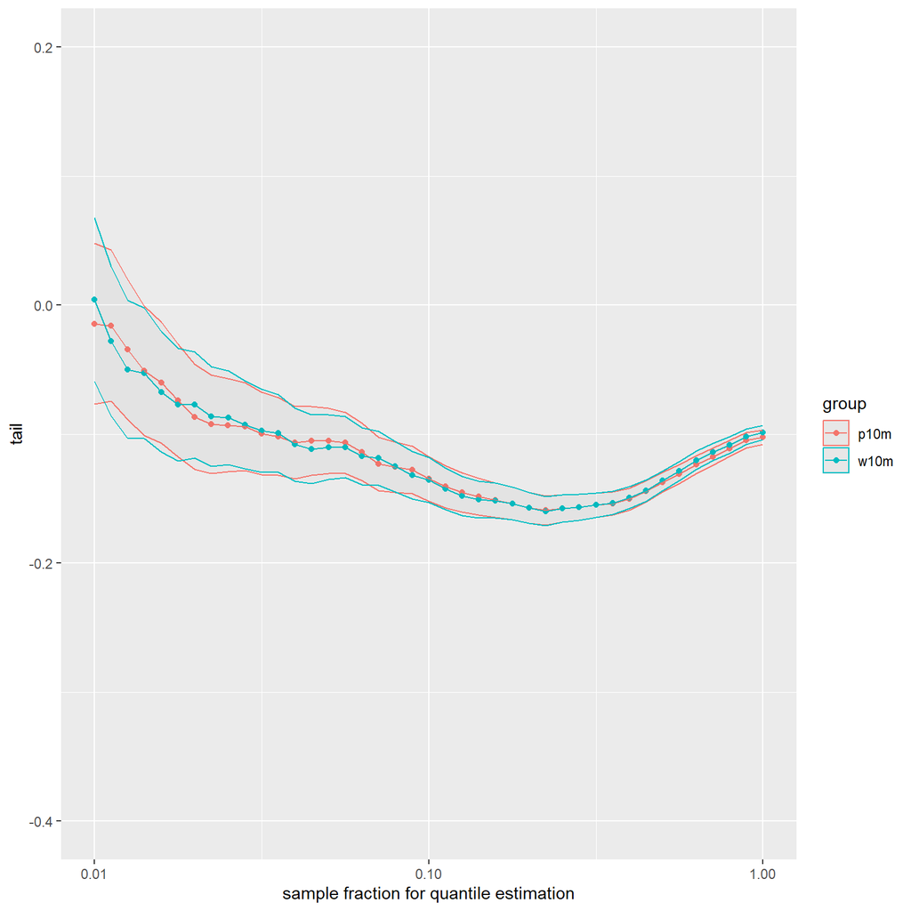

```r
stability_est_GP(data_model = Cabauw_RACMO, data_measure = Cabauw_RACMO, col_model='p10m',col_measure='w10m', timestep_model=3,timestep_measure=3,fix_y = c(-0.4,0.2), parameter='tail',overlap = T,peak_frac = 0.3,winter=T,label=c('p10m','w10m',''))
```

The tail of potential wind and normal wind behave practicaly exactly the same.

# 2 Stability

## 2.1 measurements

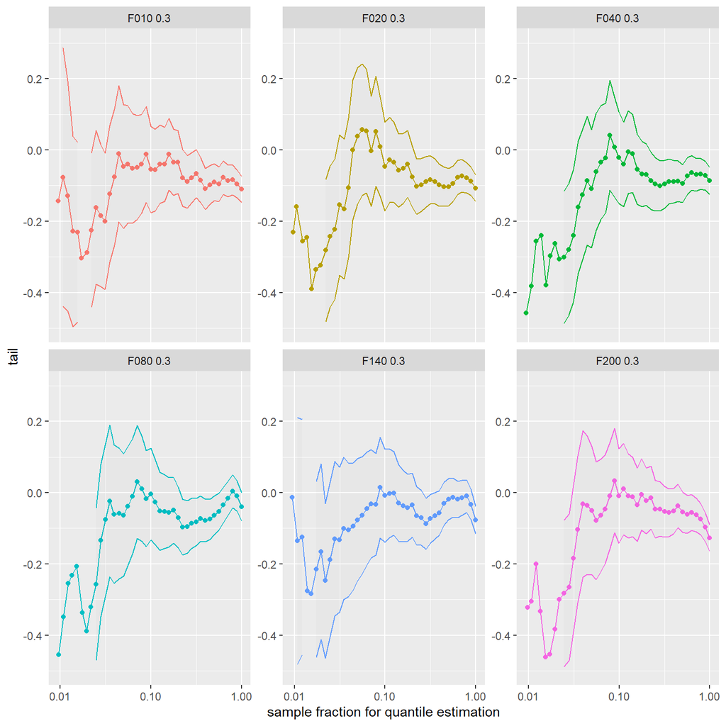

```r
tim_h = tailindexplot_col(Cabauw_measure,12*6,columns = c("F010","F020","F040","F080","F140","F200"),fraq_min = 2,fix_y = T,parameter = 'tail',winter = T)
print(tim_h$gg+ylim(c(-0.5,0.3)))
```

Here we have the stability of 10 min mean wind speed for different heights. We see that the tail index behave almost the same for every height.

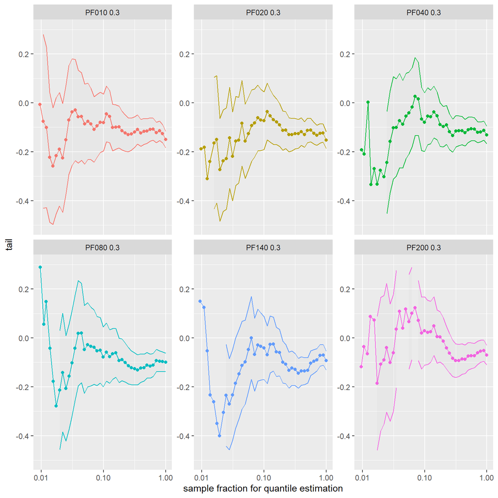

```r
tim_hx = tailindexplot_col(Cabauw_measure,12*6,columns = c("PF010","PF020","PF040","PF080","PF140","PF200"),fraq_min = 2,fix_y = T,parameter = 'tail',winter = T)
print(tim_hx$gg+ylim(c(-0.5,0.3)))
```

Here we have the stability of 3s gust wind speed for different heights. We see that the tail index behave almost the same for every height. And is similar than for 10min mean ws but a bit lower.

## 2.2 RACMO

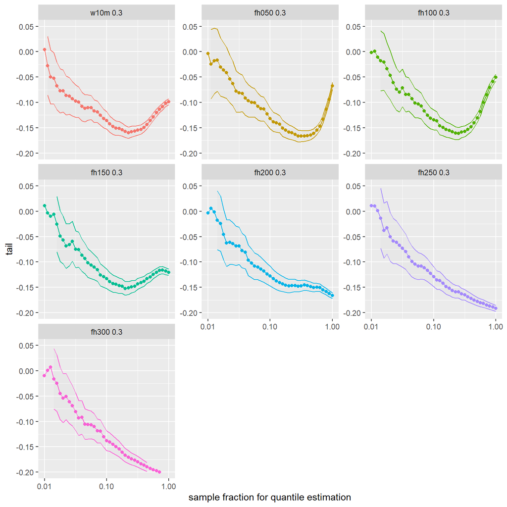

```r
tic_h = tailindexplot_col(Cabauw_RACMO,4,columns = c("w10m","fh050","fh100","fh150","fh200","fh250","fh300"),fraq_min = 2,fix_y = T,parameter = 'tail',winter = T)

print(tic_h$gg + ylim(c(-0.2,0.05)) + theme(legend.position = "none"))
```

Here we have the stability of 3h sample wind speed for different heights. We see that the tail index behave almost the same for every height.

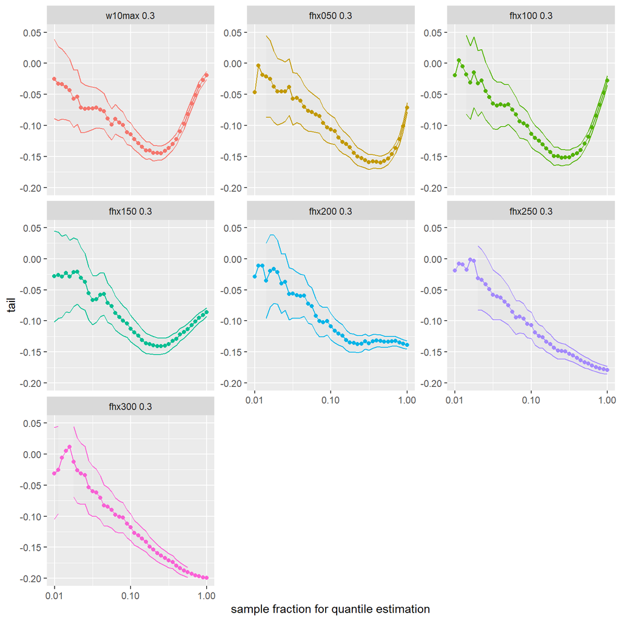

```r
tic_hx = tailindexplot_col(Cabauw_RACMO,4,columns = c("w10max","fhx050","fhx100","fhx150","fhx200","fhx250","fhx300"),fraq_min = 2,fix_y = T,parameter = 'tail',winter = T)

print(tic_hx$gg + ylim(c(-0.2,0.05)) + theme(legend.position = "none"))
```

### 2.2.1 Is it that different if we take only 18y on RACMO ?

Sample 18y in RACMO to see if we can have similar result than Cabauw measurements…

```
[1] 6.184882
================================================================================[1] 5.615971
================================================================================================================================================================
```

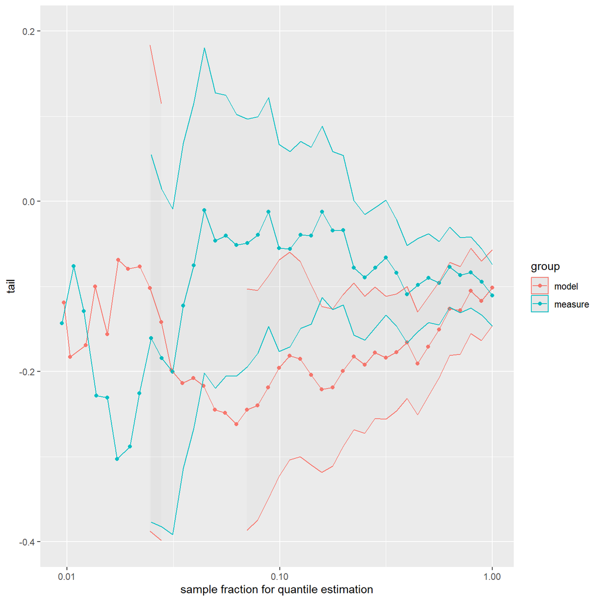

```
$df
             p         val         lb           ub   group
1  0.009671180 -0.11892450 -0.5648020  0.326953029   model
2  0.010315925 -0.18268614 -0.5831626  0.217790292   model
3  0.012250161 -0.16903760 -0.5539734  0.215898238   model
4  0.013539652 -0.09998468 -0.4849205  0.284951159   model
5  0.015473888 -0.15599538 -0.5072680  0.195277255   model
6  0.017408124 -0.06872464 -0.4199973  0.282547994   model
7  0.019342360 -0.07960199 -0.4089561  0.249752151   model
8  0.021921341 -0.07669803 -0.3870485  0.233652432   model
9  0.024500322 -0.10199219 -0.3875121  0.183527730   model
10 0.027724049 -0.14185654 -0.3983485  0.114635422   model
11 0.030947776 -0.19836726 -0.4251463  0.028411787   model
12 0.034816248 -0.21357356 -0.4233271 -0.003820012   model
13 0.039329465 -0.20754754 -0.4064116 -0.008683438   model
```

[output cut: 72 more lines]

```r
yr_sample = sample(Cabauw_RACMO$Year,18,replace = FALSE)

yr_index = which(Cabauw_RACMO$Year %in% yr_sample)

new_data = Cabauw_RACMO[yr_index,]

stability_est_GP(data_model = new_data, data_measure = Cabauw_measure, col_model='w10m',col_measure='F010', timestep_model=3,timestep_measure=1/6,fix_y = c(-0.4,0.2), parameter='tail',overlap = T,peak_frac = 0.3,winter = T)
```

> The result is really unstable and depends on the years selected. Sometimes it can fit with the measurements and sometimes it doesn’t fit at all. This means that looking for a stable tail index (as a function of the sample fraction) makes no sense for the observations. **So it confirms our hypothesis that we have to rely on RACMO for a good estimate of the tail index**.

### 2.2.2 Interpolation and color plot for tail index

#### 2.2.2.1 Interpolation RACMO on all heights

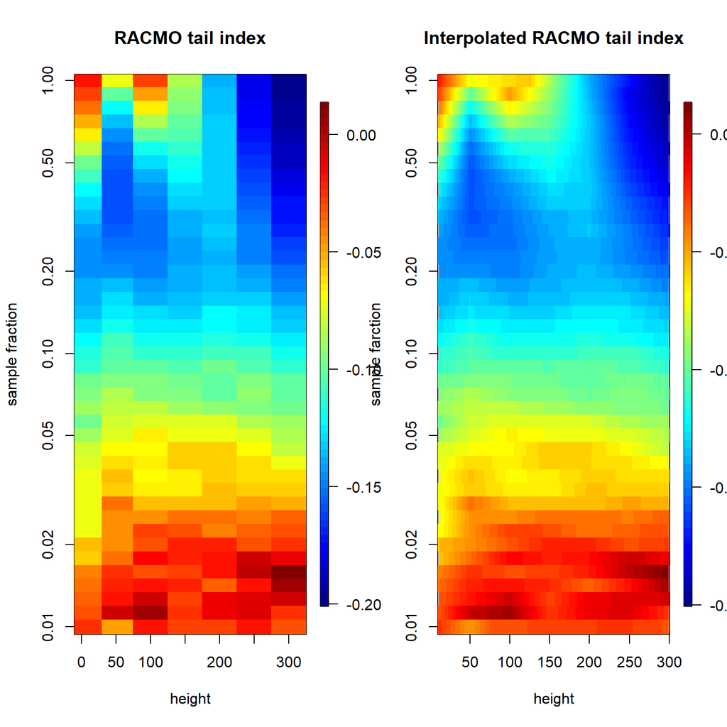

```r
interpoints = tic_hx$df
interpoints = split(interpoints,interpoints$group)

interpoints = simplify2array(interpoints)

cn = colnames(interpoints)
rn = rownames(interpoints)

interpoints = array(unlist(interpoints),dim = c(41,length(rn),length(cn)))

# Original data
h <-  c(10,50,100,150,200,250,300)
p <-  interpoints[,1,1]
data <- interpoints[,2,]


############################## INTERPOLATION
# New h values
h_new <- seq(10, 300, 1) # Replace 100 with the number of new h values you want
# Converting the matrix to vectors
h_expanded <- rep(h, each = length(p))
p_expanded <- rep(p, times = length(h))
z_values <- as.vector(data)  # Transpose to match the (h, p) structure

# Interpolating along the h dimension
interpolation_result <- akima::interp(x = h_expanded, y = p_expanded, z = z_values, xo = h_new, yo = p)

interpolated_data <- matrix(interpolation_result$z, nrow = length(h_new), ncol = length(p))

##############################



# Plotting the original and interpolated data for visualization (optional)
par(mfrow = c(1, 2))

fields::image.plot(h, p, t(data), main = "RACMO tail index", xlab = "height", ylab = "sample fraction", log = "y")

# Plot the interpolated data with a color scale and log y-axis
fields::image.plot(h_new, p, interpolated_data, main = "Interpolated RACMO tail index", xlab = "height", ylab = "sample farction", log = "y")
```

color plot to show the interpolation.

#### 2.2.2.2 Color plot with confidence

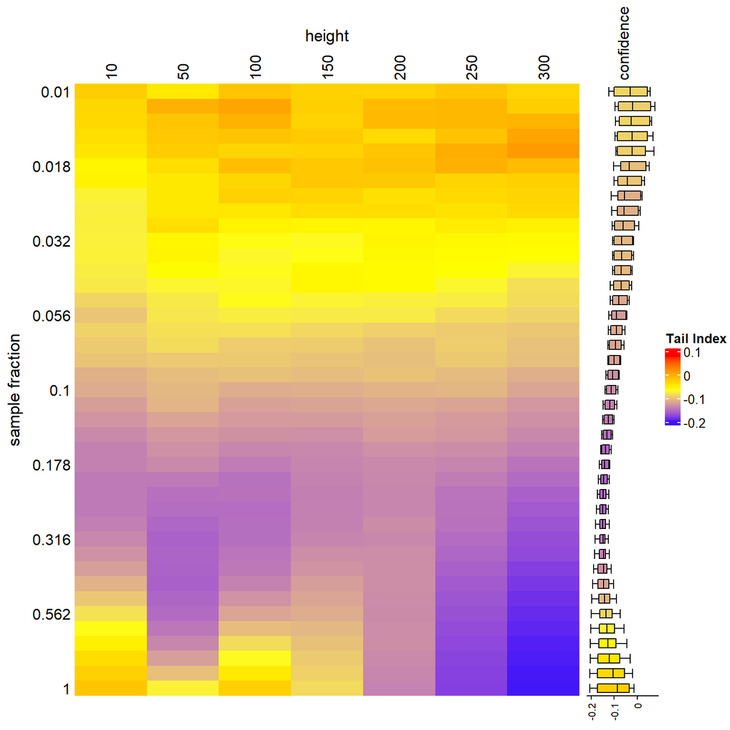

```r
library(ComplexHeatmap)
library(circlize)

zlim = range(interpoints[,c(2,3,4),])

rownames(data) <- rep("", length(p))

rownames(data)[seq(1, length(p), by = 5)] <- round(p,digits = 3)[seq(1, length(p), by = 5)]

colnames(data) <- h
# Define the heatmap
ht <- Heatmap(data,
              name = "RACMO tail index",
              column_title = "height",
              row_title = "sample fraction",
              row_names_side = "left",
              column_names_side = "top",
              col = colorRamp2(c(zlim[1], mean(zlim), zlim[2]), c("blue", "yellow", "red")),
              cluster_rows = FALSE,
              cluster_columns = FALSE,
              show_column_names = TRUE,
              show_row_names = TRUE,
              heatmap_legend_param = list(title = "Tail Index"))


bp = cbind(interpoints[,3,],interpoints[,4,])

# Create bar annotation
ha <- rowAnnotation(
  confidence = anno_boxplot(bp, border = FALSE, gp = gpar(fill = colorRamp2(c(zlim[1], mean(zlim), zlim[2]), c("blue", "yellow", "red"))(bp)),height = unit(10,"cm")),
  annotation_name_side = "top"
)


# Draw the heatmap with annotation
draw(ht+ha, heatmap_legend_side = "right", annotation_legend_side = "right")
```

Color plot for estimated tail index at all heights for RACMO data at Cabauw.

#### 2.2.2.3 Compare to measurements

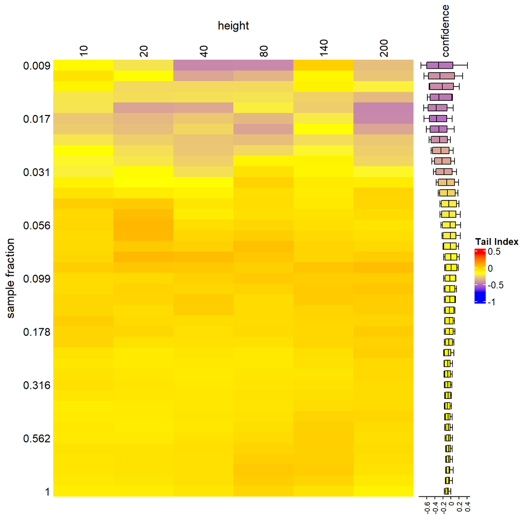

```r
interpoints = tim_h$df
interpoints = split(interpoints,interpoints$group)

interpoints = simplify2array(interpoints)

cn = colnames(interpoints)
rn = rownames(interpoints)

interpoints = array(unlist(interpoints),dim = c(41,length(rn),length(cn)))




zlim = range(interpoints[,c(2,3,4),])

data = interpoints[,2,]
h <-  c(10,20,40,80,140,200)
p <-  interpoints[,1,1]

rownames(data) <- rep("", length(p))

rownames(data)[seq(1, length(p), by = 5)] <- round(p,digits = 3)[seq(1, length(p), by = 5)]

colnames(data) <- h
# Define the heatmap
ht <- Heatmap(data,
              name = "RACMO tail index",
              column_title = "height",
              row_title = "sample fraction",
              row_names_side = "left",
              column_names_side = "top",
              col = colorRamp2(c(zlim[1], mean(zlim), zlim[2]), c("blue", "yellow", "red")),
              cluster_rows = FALSE,
              cluster_columns = FALSE,
              show_column_names = TRUE,
              show_row_names = TRUE,
              heatmap_legend_param = list(title = "Tail Index"))


bp = cbind(interpoints[,3,],interpoints[,4,])

# Create bar annotation
ha <- rowAnnotation(
  confidence = anno_boxplot(bp, border = FALSE, gp = gpar(fill = colorRamp2(c(zlim[1], mean(zlim), zlim[2]), c("blue", "yellow", "red"))(bp)),height = unit(10,"cm")),
  annotation_name_side = "top"
)


# Draw the heatmap with annotation
draw(ht+ha, heatmap_legend_side = "right", annotation_legend_side = "right")
```

## 2.3 GW

### 2.3.1 stability for all heights

#### 2.3.1.1 Measurements

```
[1] "F010 0.4"
[1] 498672
[1] 4.78
[1] "F010 0.3"
[1] 498672
[1] 5.615971
[1] "F010 0.2"
[1] 498672
[1] 6.70107
[1] "F010 0.1"
[1] 498672
[1] 8.429999
```

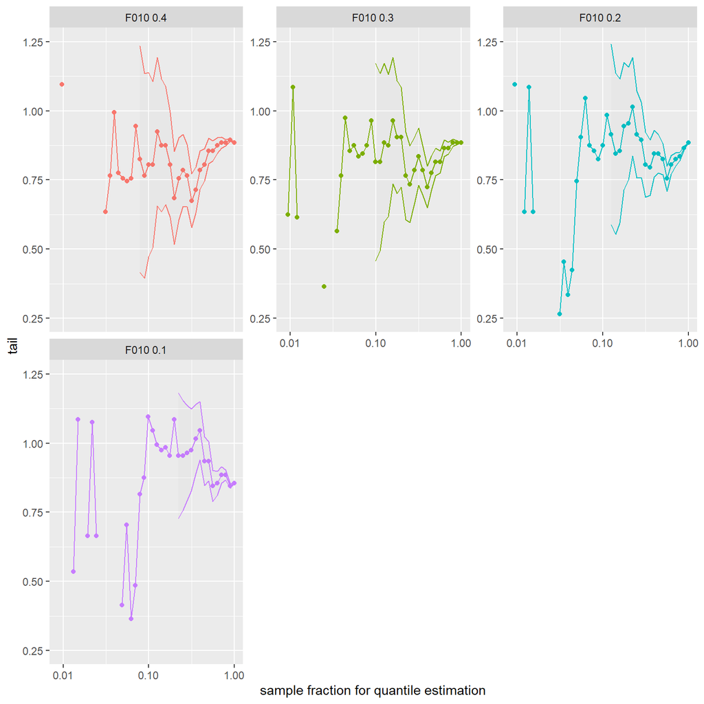

```
$df
              p    val           lb        ub    group
1   0.009741476  1.095 -1.026096848 3.2160968 F010 0.4
2   0.010865493 -0.655 -2.579852576 1.2698526 F010 0.4
3   0.012364181 -0.115 -1.876527399 1.6465274 F010 0.4
4   0.013862870 -0.765 -2.371532990 0.8415330 F010 0.4
5   0.015361559 -0.845 -2.332072578 0.6420726 F010 0.4
6   0.017234919 -0.775 -2.140629120 0.5906291 F010 0.4
7   0.019482952 -0.025 -1.281056464 1.2310565 F010 0.4
8   0.022105658  0.225 -0.919222448 1.3692224 F010 0.4
9   0.024728363  0.065 -0.983382165 1.1133822 F010 0.4
10  0.027725740  0.215 -0.746246823 1.1762468 F010 0.4
11  0.031097789  0.635 -0.247374363 1.5173744 F010 0.4
12  0.035219183  0.765 -0.035762327 1.5657623 F010 0.4
13  0.039340577  0.995  0.260780573 1.7292194 F010 0.4
```

[output cut: 154 more lines]

```r
tailindexplot_col(Cabauw_measure,12*6,columns = c("F010","F010","F010","F010"),fraq_min = 2,fix_y = c(0.25,1.25),parameter = 'tail',peak_frac = c(0.4,0.3,0.2,0.1),winter=T,method = 'GW')
```

#### 2.3.1.2 Weather model

```
[1] "w10m 0.4"
[1] 1512912
[1] 5.418773
[1] "w10m 0.3"
[1] 1512912
[1] 6.175583
[1] "w10m 0.2"
[1] 1512912
[1] 7.149905
[1] "w10m 0.1"
[1] 1512912
[1] 8.602802
```

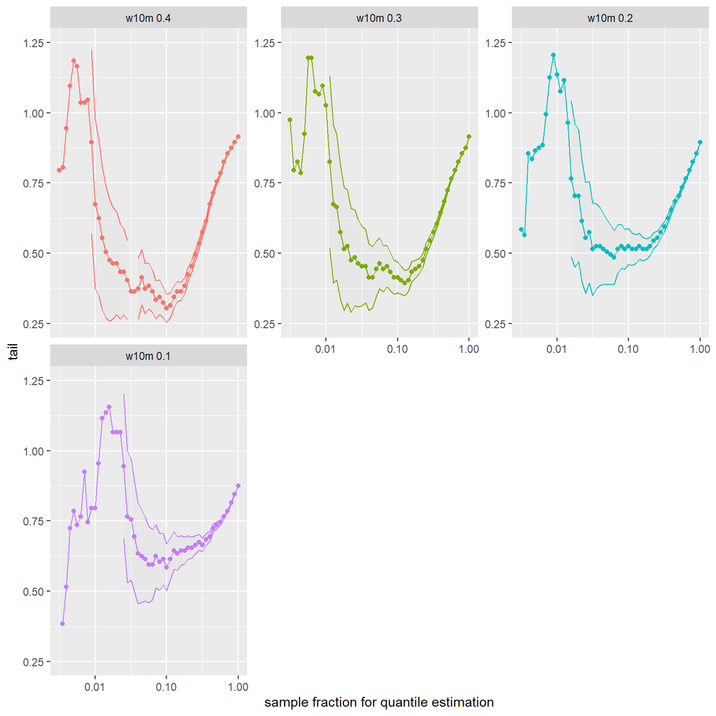

```
$df
              p   val          lb        ub    group
1   0.003152379 0.795  0.13109930 1.4589007 w10m 0.4
2   0.003538911 0.805  0.19065557 1.4193444 w10m 0.4
3   0.003968390 0.945  0.37572853 1.5142715 w10m 0.4
4   0.004457997 1.095  0.56829168 1.6217083 w10m 0.4
5   0.004999141 1.185  0.69747798 1.6725220 w10m 0.4
6   0.005617591 1.165  0.71489387 1.6151061 w10m 0.4
7   0.006304759 1.035  0.61955727 1.4504427 w10m 0.4
8   0.007069232 1.035  0.65112397 1.4188760 w10m 0.4
9   0.007936781 1.045  0.69074888 1.3992511 w10m 0.4
10  0.008907404 0.895  0.56849987 1.2215001 w10m 0.4
11  0.009989692 0.675  0.37422630 0.9757737 w10m 0.4
12  0.011209414 0.625  0.34785623 0.9021438 w10m 0.4
13  0.012583748 0.555  0.29989169 0.8101083 w10m 0.4
```

[output cut: 194 more lines]

```r
tailindexplot_col(Cabauw_RACMO,4,columns = c("w10m","w10m","w10m","w10m"),fraq_min = 2.5,fix_y = c(0.25,1.25),parameter = 'tail',peak_frac = c(0.4,0.3,0.2,0.1),winter=T,method = 'GW')
```

### 2.3.2 Stability with model

On regarde si la tail index est similaire entre le model et les mesures pour voir s’il est ok d’utiliser le model pour estimer la tail.

```
[1] 7.786597
[1] 7.46
```

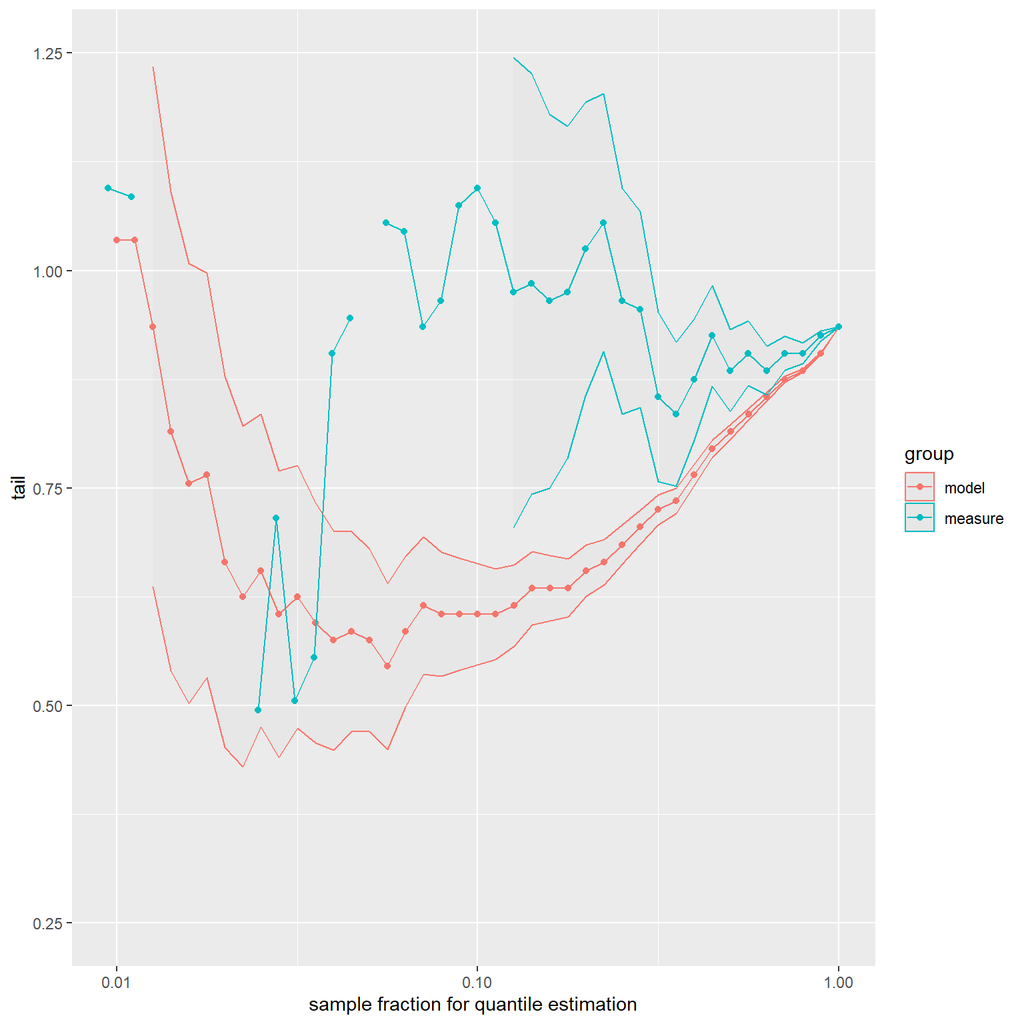

```
$df
            p    val         lb        ub   group
1  0.00999029  1.035  0.6827694 1.3872306   model
2  0.01120691  1.035  0.7103082 1.3596918   model
3  0.01257560  0.935  0.6361179 1.2338821   model
4  0.01410807  0.815  0.5400275 1.0899725   model
5  0.01583941  0.755  0.5022245 1.0077755   model
6  0.01776962  0.765  0.5325503 0.9974497   model
7  0.01994549  0.665  0.4516289 0.8783711   model
8  0.02237872  0.625  0.4291557 0.8208443   model
9  0.02510441  0.655  0.4752841 0.8347159   model
10 0.02816934  0.605  0.4403436 0.7696564   model
11 0.03160862  0.625  0.4742162 0.7757838   model
12 0.03546904  0.595  0.4571040 0.7328960   model
13 0.03979739  0.575  0.4490088 0.7009912   model
```

[output cut: 72 more lines]

```r
stability_est_GW(data_model = Cabauw_RACMO, data_measure = Cabauw_measure, col_model='w10m',col_measure='F010', timestep_model=3,timestep_measure=1/6,fix_y = c(0.25,1.25), parameter='tail',overlap = T,peak_frac = 0.1,winter = F)
```

```
[1] 16.06679
[1] 13.91821
```

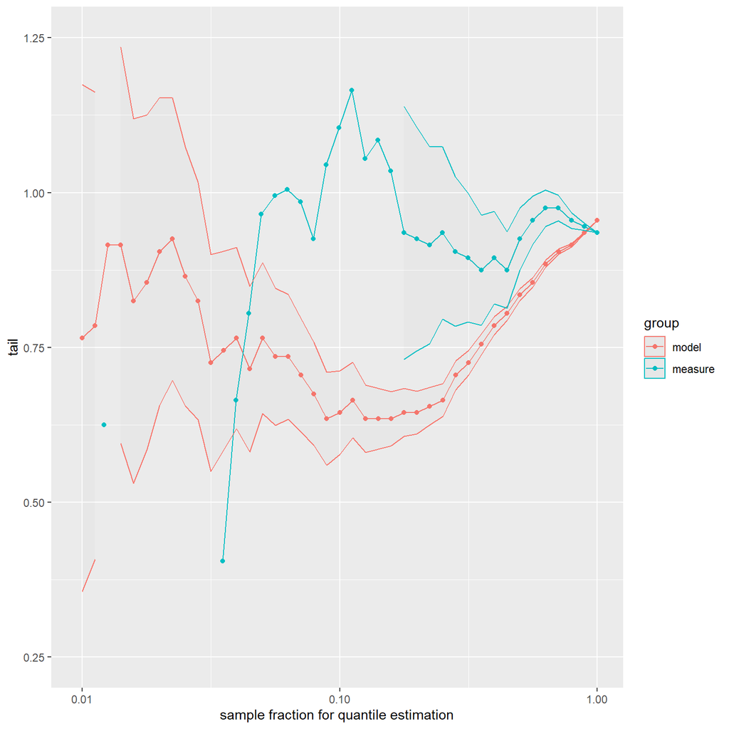

```
$df
             p    val          lb        ub   group
1  0.009980103  0.765  0.35567690 1.1743231   model
2  0.011211825  0.785  0.40804765 1.1619524   model
3  0.012569877  0.915  0.56728841 1.2627116   model
4  0.014117424  0.915  0.59514482 1.2348552   model
5  0.015838676  0.825  0.53090197 1.1190980   model
6  0.017765215  0.855  0.58450093 1.1254991   model
7  0.019944415  0.905  0.65652447 1.1534755   model
8  0.022376275  0.925  0.69686468 1.1531353   model
9  0.025108170  0.865  0.65582903 1.0741710   model
10 0.028171683  0.825  0.63334981 1.0166502   model
11 0.031614187  0.725  0.54964687 0.9003531   model
12 0.035467265  0.745  0.58457201 0.9054280   model
13 0.039794081  0.765  0.61839839 0.9116016   model
```

[output cut: 72 more lines]

```r
stability_est_GW(data_model = Cabauw_RACMO, data_measure = Cabauw_measure, col_model='fhx200',col_measure='F200', timestep_model=3,timestep_measure=1/6,fix_y = c(0.25,1.25), parameter='tail',overlap = T,winter=F, peak_frac=  0.1)
```

# 3 Wind Speed Estimation with and without tail estimated with weather model

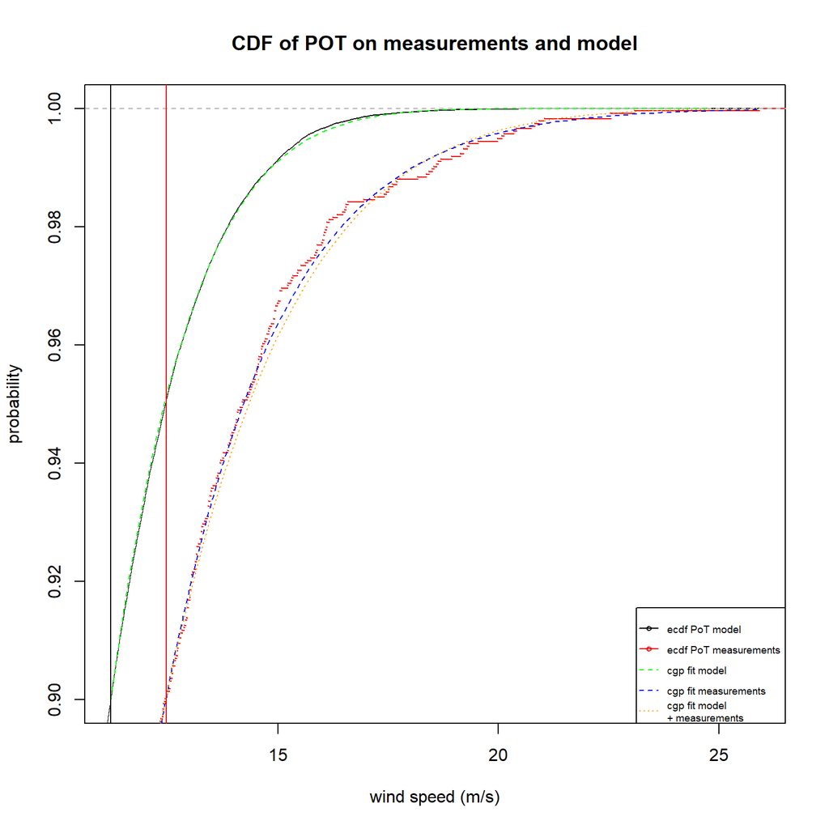

```r
BM = WSEst_model_to_measure_BM_2(data_model = Cabauw_RACMO,data_measure = Cabauw_measure,col_model = "w10m",col_measure = "F010",Nb_model = 100,Nb_measure = 100,length.out = 1000)
GP = WSEst_model_to_measure_GP_2(data_model = Cabauw_RACMO,data_measure = Cabauw_measure,col_model = "w10m",col_measure = "F010", timestep_model = 3,timestep_measure = 1/6,th_model = 0.1,th_measure = 0.1,length.out = 1000,winter = T)
```

```r
GW = WSEst_model_to_measure_GW_2(data_model = Cabauw_RACMO,data_measure = Cabauw_measure,col_model = "w10m",col_measure = "F010", timestep_model = 3,timestep_measure = 1/6,th_model = 0.1,th_measure = 0.1,length.out = 1000,winter = T)
```

## 3.1 Generalized Extreme Value Distribution with Block Maxima Method

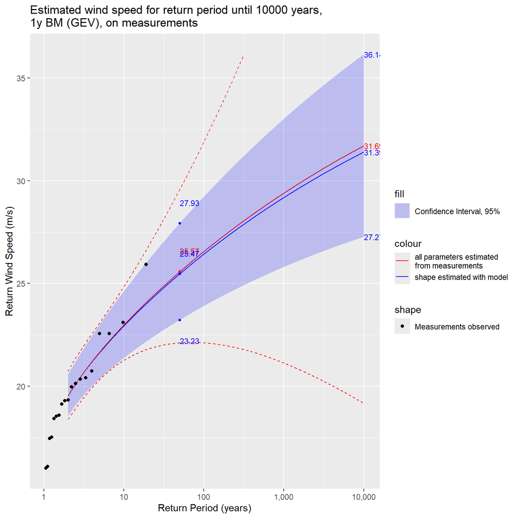

```r
print(BM$gg)
```

## 3.2 Generalized Pareto Distribution with Peak over Threshold Method

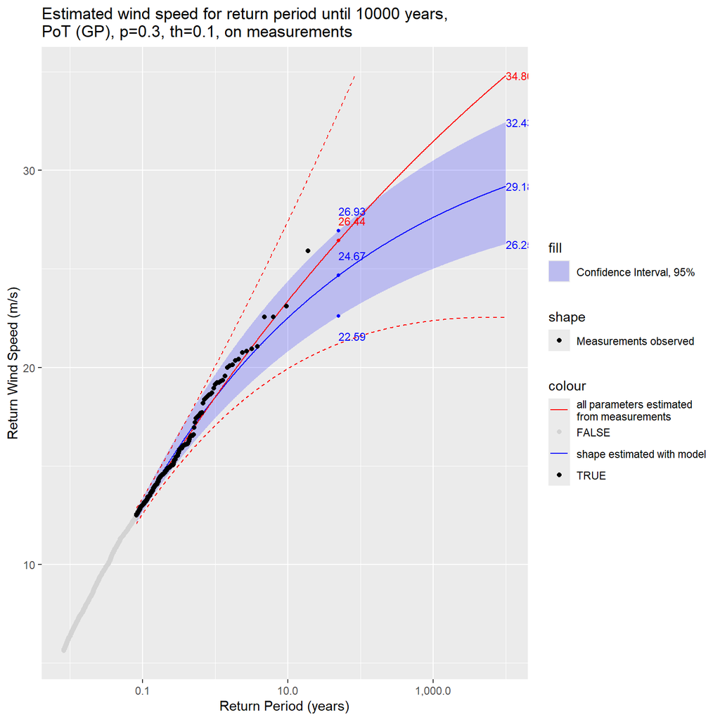

```r
print(GP$gg)
```

## 3.3 Generalized Weibull Distribution with Peak over Threshold Method

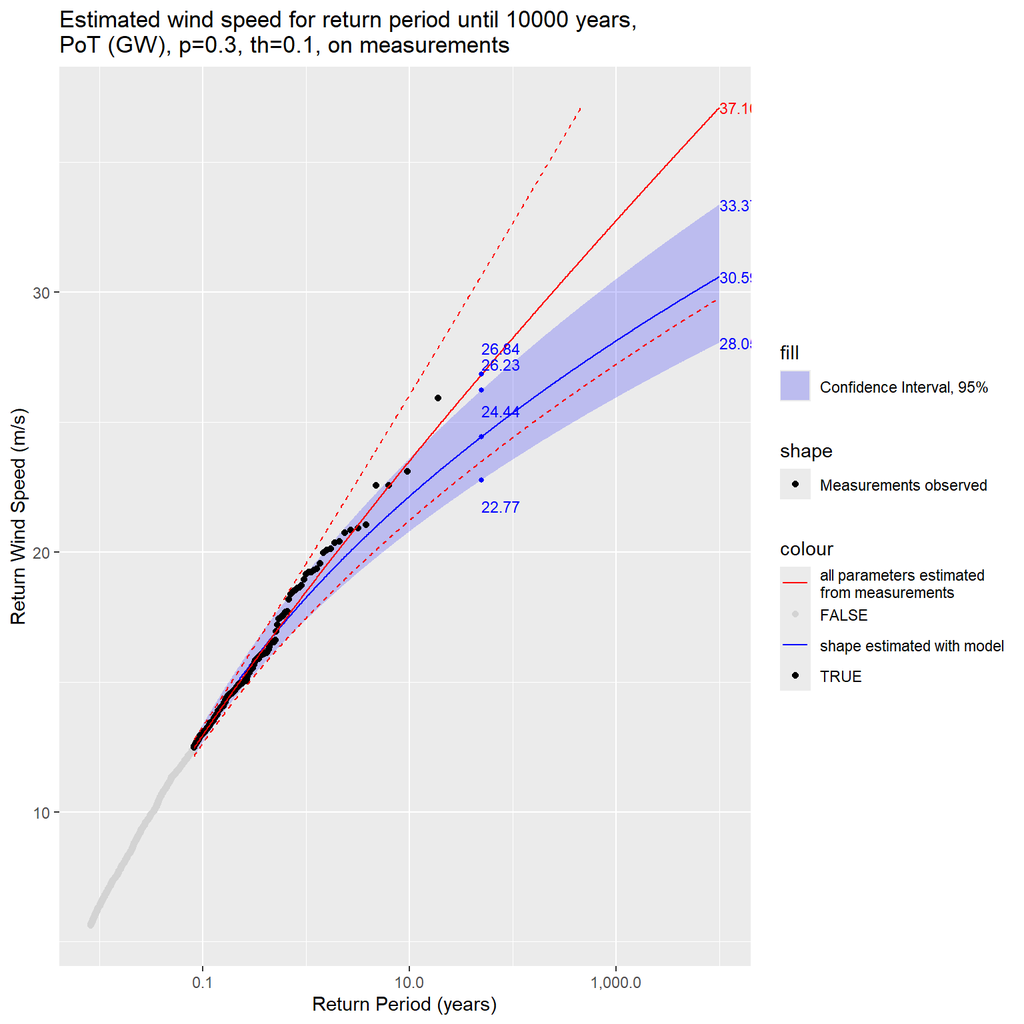

```r
print(GW$gg)
```

# 4 Models Comparison

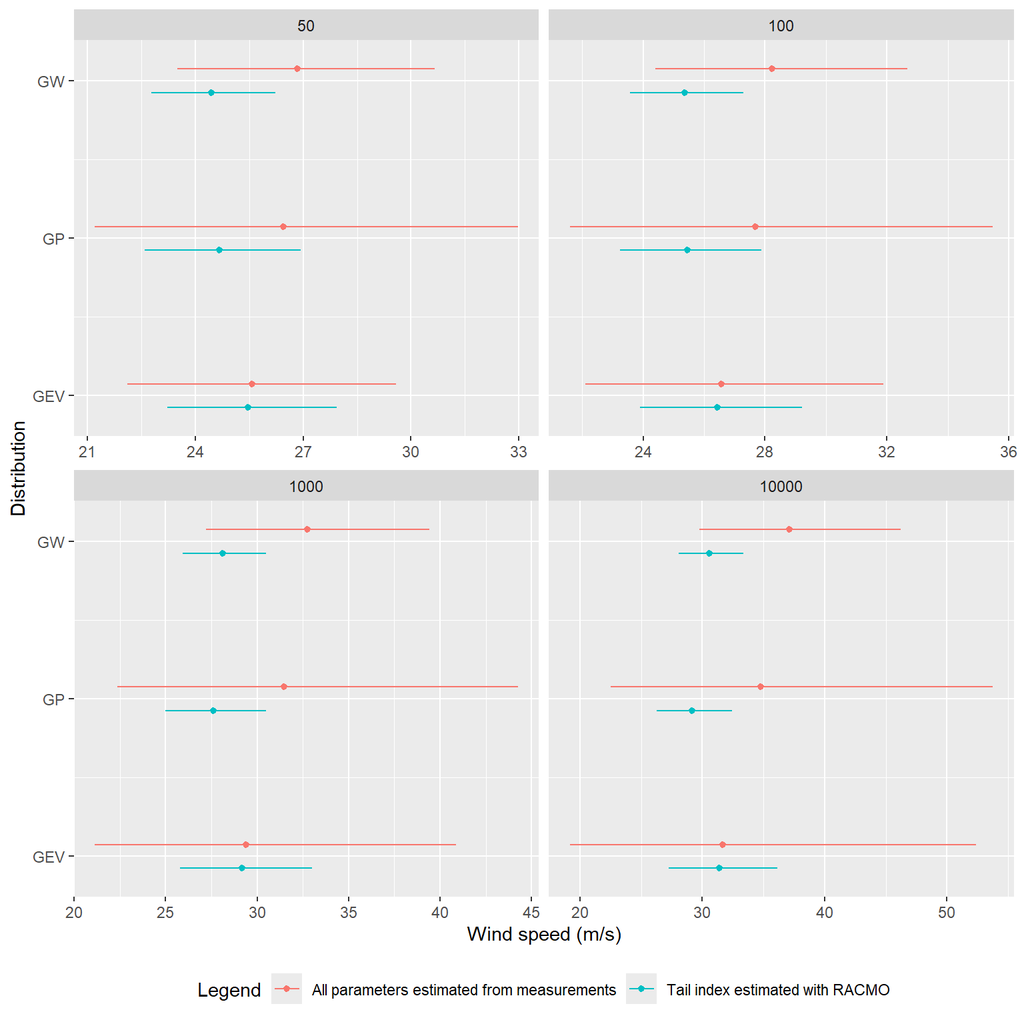

```r
df_plot <- rbind(cbind(BM$df,distrib='GEV'),cbind(GP$df,distrib='GP'),cbind(GW$df,distrib='GW'))

i50 <- df_plot %>%
    slice(which(abs(return - 50)==0))

i100 <- df_plot %>%
    slice(which(abs(return - 100)==0))

i1000 <- df_plot %>%
    slice(which(abs(return - 1000)==0))

i10000 <- df_plot %>%
    slice(which(abs(return - 10000)==0))

df_plot <- rbind(i50,i100,i1000,i10000)

df_plot$distrib_num <- as.numeric(factor(df_plot$distrib, levels = c('GEV', 'GP', 'GW')))

original = cbind(df_plot[c('return',"original",'lb_o','ub_o','sd_o',"distrib","distrib_num")],group = 'All parameters estimated from measurements')
model_est = cbind(df_plot[c('return',"model_est",'lb','ub','sd',"distrib","distrib_num")],group = 'Tail index estimated with RACMO')
colnames(original)=c('return',"val",'lb','ub','sd',"distrib","distrib_num","group")
colnames(model_est)=c('return',"val",'lb','ub','sd',"distrib","distrib_num","group")
df_plot = rbind(original,model_est)


# Plot with vertical dodge
ggplot(df_plot, aes(y = distrib_num,colour = group)) +
  facet_wrap(~return, scales = "free_x") +
  geom_pointrange(aes(x = val, xmin = lb, xmax = ub),
                  size = 0.2,
                  position = ggstance::position_dodge2v(0.3)) +
  scale_y_continuous(breaks = 1:3, labels = c('GEV', 'GP', 'GW')) +
  labs(x = 'Wind speed (m/s)', y = 'Distribution', color = 'Legend') +
  theme(legend.position = "bottom")
```

# 5 Save results for matlab

```r
out <- as.list(BM$df[c('return','proba','original','sd_o','model_est','sd')])
out$points <- BM$points
out$timedelta <- 1
writeMat("../../../DATA_for_Laurine/GEV_Cabauw_est.mat", GEV_est = out)

out <- as.list(GP$df[c('return','proba','original','sd_o','model_est','sd')])
out$points <- GP$points
out$timedelta <- GP$timestep
writeMat("../../../DATA_for_Laurine/GP_Cabauw_est.mat", GP_est = out)

out <- as.list(GW$df[c('return','proba','original','sd_o','model_est','sd')])
out$points <- GW$points
out$timedelta <- GW$timestep
writeMat("../../../DATA_for_Laurine/GW_Cabauw_est.mat", GW_est = out)
```